# Video Games Sales

2022-06-13

## Introduzione al dataset

Il dataset analizzato è preso dal sito “kaggle”. In esso troviamo il numero delle vendite (in milioni di copie) di innumerevoli videogames. I dati presenti partono dal 1980 ed arrivano al 2016.

[figure not shown]

## Cosa vogliamo scoprire?

1. Quanti giochi sono stati pubblicati negli anni
2. Quali sono state le vendite annuali per “regione”
3. Quali sono stati i 5 giochi più venduti
4. Quali siano i generi più venduti nelle varie “regioni”  
   e molto altro ancora…

[figure not shown]

## Pubblicazione dei giochi negli anni

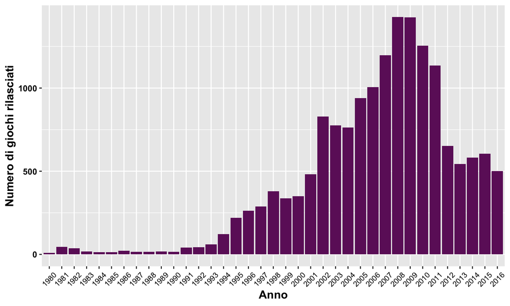

## Vendite annuali per “regione”

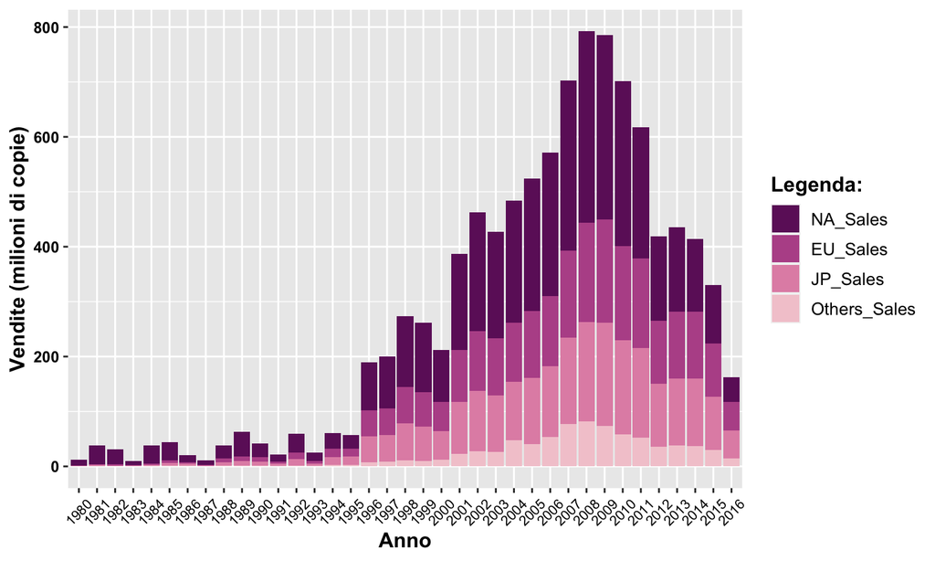

L’andamento delle vendite varia in modo (circa) proporzionale al variare del numero delle pubblicazioni di giochi.

## I 5 giochi più venduti al mondo

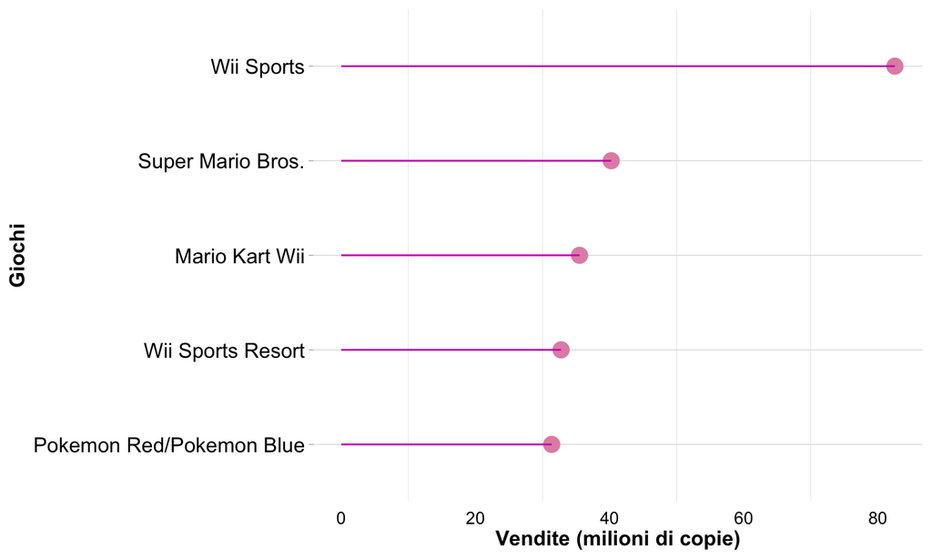

## I 5 giochi più venduti per “regione”

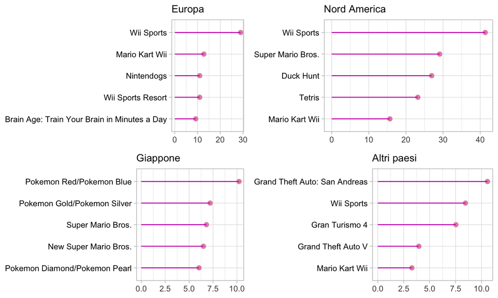

Diversa distribuzione per “regione”.

## Vendite per genere e “regione”

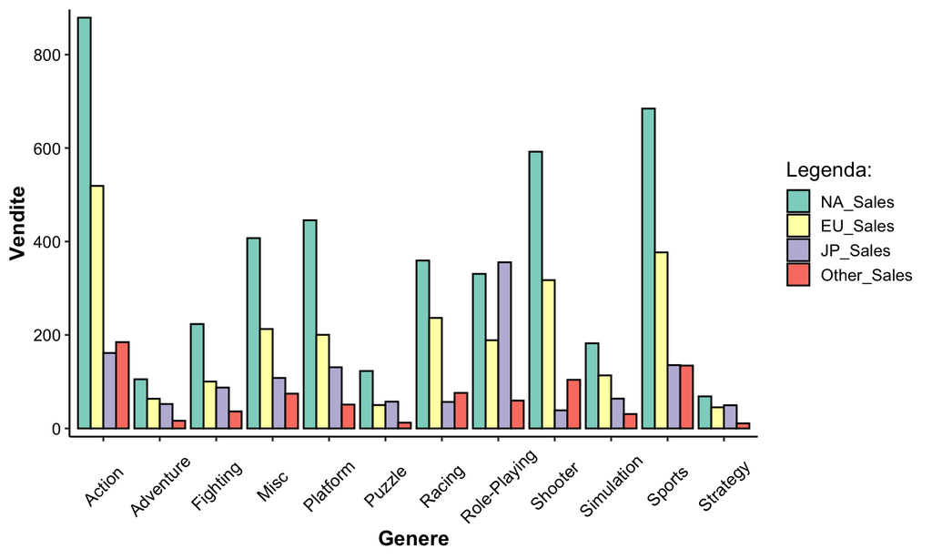

## Popolarità dei generi negli anni

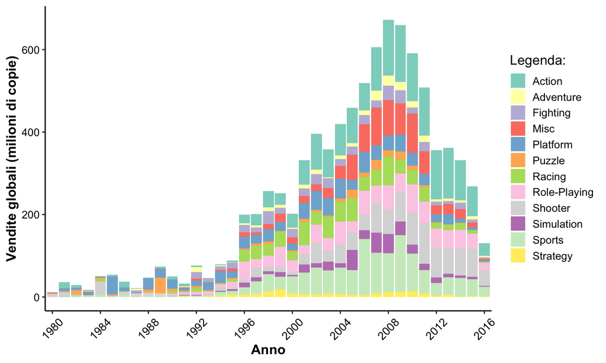

Mediamente, i generi più redditizi sono anche quelli più popolari.

## I 10 editori più attivi

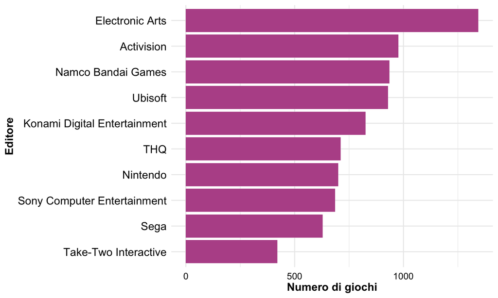

## I 10 editori con il maggior numero di vendite

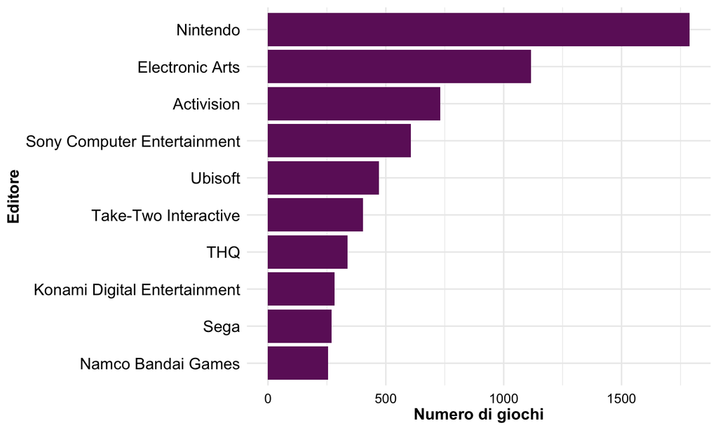

Gli editori con il maggior numero di pubblicazioni non sono sempre quelli con il maggior numero di vendite.

## Le 20 piattaforme con più giochi

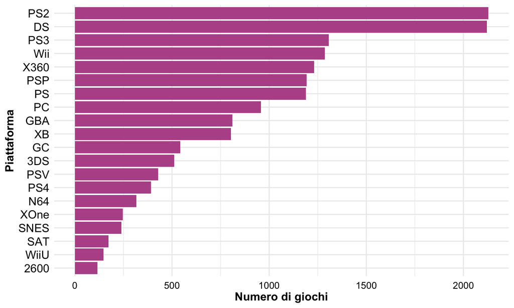

Le piattaforme pù “mature” sono quelle con il maggior numero di giochi pubblicati.

## Vendite per piattaforme

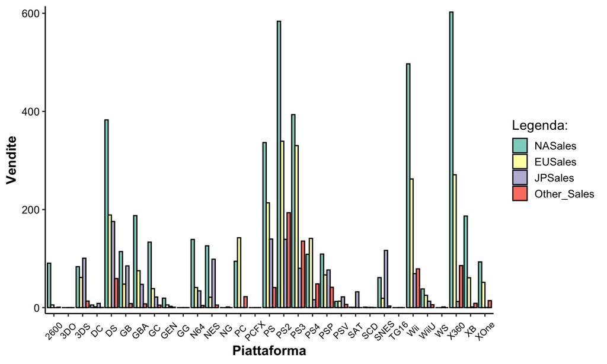

Le piattaforme con il maggior numero di vendite sono (circa) quelle con il maggior numero di giochi.

## Classificazione

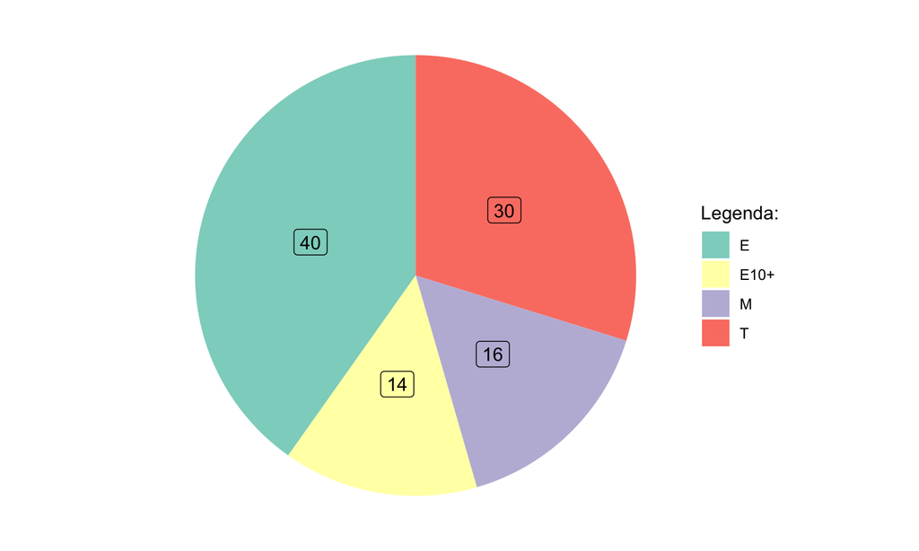

La classificazione identifica a quale pubblico sia destinato ogni singolo gioco (in base ai contenuti presenti in esso).  
Per riassumere quanto presente nella classificazione:  
E: per tutte le età  
E10: per un pubblico di 10+ anni  
M: per un pubblico di 17+ anni  
T: per un pubblico di 13+ anni

## Grazie dell’attenzione!

[figure not shown]

## Sitografia/bibliografia

Dataset: https://www.kaggle.com/datasets/sidtwr/videogames-sales-dataset  
Spunti per grafici: https://r-charts.com/, http://www.sthda.com/english/wiki/ggplot2-essentials, https://www.kaggle.com/code/mfaaris/15-visualization-and-analysis-with-r Rating: https://www.esrb.org/ratings-guide/